# Economic freedom Index Regression Model

Lohansen

2019-08-13

# Read Data

```r
library(tidyverse)
library(dplyr)
library(lmtest)
library(car)
df <- read_csv("economic_freedom_index2019_data.csv")
head(df)
```

```
## # A tibble: 6 x 34
##   CountryID `Country Name` WEBNAME Region `World Rank` `Region Rank`
##       <dbl> <chr>          <chr>   <chr>  <chr>        <chr>
## 1         1 Afghanistan    Afghan~ Asia-~ 152          39
## 2         2 Albania        Albania Europe 52           27
## 3         3 Algeria        Algeria Middl~ 171          14
## 4         4 Angola         Angola  Sub-S~ 156          33
## 5         5 Argentina      Argent~ Ameri~ 148          26
## 6         6 Armenia        Armenia Europe 47           24
## # ... with 28 more variables: `2019 Score` <chr>, `Property Rights` <chr>,
## #   `Judical Effectiveness` <chr>, `Government Integrity` <chr>, `Tax
## #   Burden` <chr>, `Gov't Spending` <chr>, `Fiscal Health` <chr>,
## #   `Business Freedom` <chr>, `Labor Freedom` <chr>, `Monetary
## #   Freedom` <chr>, `Trade Freedom` <chr>, `Investment Freedom` <chr>,
## #   `Financial Freedom` <chr>, `Tariff Rate (%)` <chr>, `Income Tax Rate
## #   (%)` <chr>, `Corporate Tax Rate (%)` <chr>, `Tax Burden % of
## #   GDP` <chr>, `Gov't Expenditure % of GDP` <chr>, Country <chr>,
## #   `Population (Millions)` <chr>, `GDP (Billions, PPP)` <chr>, `GDP
## #   Growth Rate (%)` <chr>, `5 Year GDP Growth Rate (%)` <chr>, `GDP per
## #   Capita (PPP)` <chr>, `Unemployment (%)` <chr>, `Inflation (%)` <chr>,
## #   `FDI Inflow (Millions)` <chr>, `Public Debt (% of GDP)` <chr>
```

### data manipulation

Selecting only the freedom index from the economic freedom data

```r
freedom <- df %>%
  select(`Financial Freedom`, `Investment Freedom`, `Business Freedom`, `Labor Freedom`, `Monetary\ Freedom`, `Trade Freedom`)
freedom
```

```
## # A tibble: 186 x 6
##    `Financial Free~ `Investment Fre~ `Business Freed~ `Labor Freedom`
##    <chr>            <chr>            <chr>            <chr>
##  1 10               10               49.2             60.4
##  2 70               70               69.3             52.7
##  3 30               30               61.6             49.9
##  4 40               30               55.7             58.8
##  5 60               55               56.4             46.9
##  6 70               75               78.3             71.4
##  7 90               80               88.3             84.1
##  8 70               90               74.9             68.7
##  9 60               60               69.5             63.9
## 10 60               50               68.5             67.5
## # ... with 176 more rows, and 2 more variables: `Monetary Freedom` <chr>,
## #   `Trade Freedom` <chr>
```

changing the type of index into numeric data

```r
freedom$`Financial Freedom` = as.numeric(freedom$`Financial Freedom`)
freedom$`Investment Freedom` = as.numeric(freedom$`Investment Freedom`)
freedom$`Business Freedom` = as.numeric(freedom$`Business Freedom`)
freedom$`Labor Freedom` = as.numeric(freedom$`Labor Freedom`)
freedom$`Monetary Freedom` = as.numeric(freedom$`Monetary Freedom`)
freedom$`Trade Freedom` = as.numeric(freedom$`Trade Freedom`)
```

checking the missing value

```r
colSums(is.na(freedom))
```

```
##  Financial Freedom Investment Freedom   Business Freedom
##                  5                  2                  1
##      Labor Freedom   Monetary Freedom      Trade Freedom
##                  2                  2                  4
```

deleting the missing value with drop_na function

```r
freedom <- freedom %>%
  drop_na(`Financial Freedom`, `Business Freedom`)
colSums(is.na(freedom))
```

```
##  Financial Freedom Investment Freedom   Business Freedom
##                  0                  0                  0
##      Labor Freedom   Monetary Freedom      Trade Freedom
##                  0                  0                  0
```

checking the data correlation

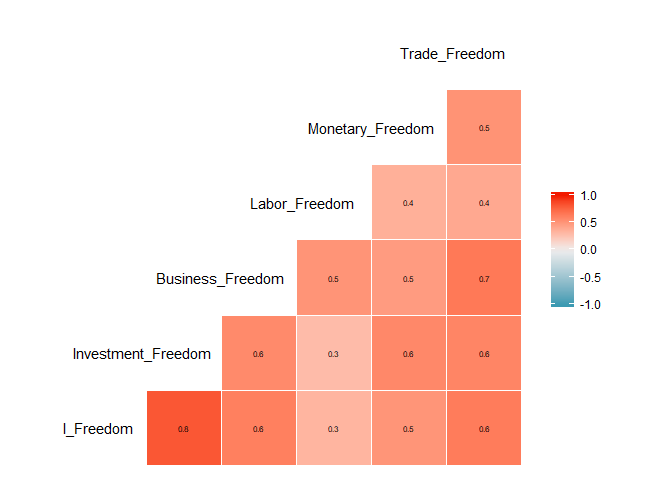

```r
library(GGally)
ggcorr(freedom, label = T,label_size = 2, hjust = .8)
```

Note : From the correlation plot above, it can be seen that the peace indexes in the data have a significant correlation, all correlation values are above 0 ang, indicating that any increase in one index will have the same effect on **financial freedom**

### modeling

make a original model that using all the index be a predictor to `Financial Freedom`

```r
model_ori <- lm(`Financial Freedom` ~., freedom)
```

steping the model

```r
step(model_ori, direction = "backward")
```

```
## Start:  AIC=854.02
## `Financial Freedom` ~ `Investment Freedom` + `Business Freedom` +
##     `Labor Freedom` + `Monetary Freedom` + `Trade Freedom`
##
##                        Df Sum of Sq   RSS    AIC
## - `Labor Freedom`       1       0.1 19358 852.02
## - `Monetary Freedom`    1      19.1 19377 852.20
## <none>                              19358 854.02
## - `Business Freedom`    1     783.0 20141 859.16
## - `Trade Freedom`       1     930.6 20288 860.47
## - `Investment Freedom`  1   14008.1 33366 950.02
##
## Step:  AIC=852.02
## `Financial Freedom` ~ `Investment Freedom` + `Business Freedom` +
##     `Monetary Freedom` + `Trade Freedom`
##
##                        Df Sum of Sq   RSS    AIC
## - `Monetary Freedom`    1      19.0 19377 850.20
## <none>                              19358 852.02
## - `Business Freedom`    1     897.3 20255 858.18
## - `Trade Freedom`       1     937.2 20295 858.53
## - `Investment Freedom`  1   14102.3 33460 948.53
##
## Step:  AIC=850.2
## `Financial Freedom` ~ `Investment Freedom` + `Business Freedom` +
##     `Trade Freedom`
##
##                        Df Sum of Sq   RSS    AIC
## <none>                              19377 850.20
## - `Business Freedom`    1     880.1 20257 856.19
## - `Trade Freedom`       1     920.9 20298 856.56
## - `Investment Freedom`  1   15661.4 35038 954.82
```

```
##
## Call:
## lm(formula = `Financial Freedom` ~ `Investment Freedom` + `Business Freedom` +
##     `Trade Freedom`, data = freedom)
##
## Coefficients:
##          (Intercept)  `Investment Freedom`    `Business Freedom`
##             -15.5361                0.5522                0.1965
##      `Trade Freedom`
##               0.2644
```

steps model recommendation

```r
model_rec <- lm(formula = `Financial Freedom` ~ `Investment Freedom` + `Business Freedom` +
    `Trade Freedom`, data = freedom)
```

checking the adjusted r squared score of both model

```r
summary(model_ori)$adj.r.squared
```

```
## [1] 0.7043331
```

```r
summary(model_rec)$adj.r.squared
```

```
## [1] 0.707404
```

checking the model

```r
summary(model_ori)
```

```
##
## Call:
## lm(formula = `Financial Freedom` ~ ., data = freedom)
##
## Residuals:
##     Min      1Q  Median      3Q     Max
## -37.149  -6.935   0.773   7.729  26.886
##
## Coefficients:
##                        Estimate Std. Error t value Pr(>|t|)
## (Intercept)          -13.883558   6.508264  -2.133  0.03431 *
## `Investment Freedom`   0.559513   0.049862  11.221  < 2e-16 ***
## `Business Freedom`     0.198461   0.074808   2.653  0.00872 **
## `Labor Freedom`        0.002326   0.064502   0.036  0.97128
## `Monetary Freedom`    -0.038323   0.092609  -0.414  0.67952
## `Trade Freedom`        0.271695   0.093939   2.892  0.00431 **
## ---
## Signif. codes:  0 '***' 0.001 '**' 0.01 '*' 0.05 '.' 0.1 ' ' 1
##
## Residual standard error: 10.55 on 174 degrees of freedom
## Multiple R-squared:  0.7126, Adjusted R-squared:  0.7043
## F-statistic: 86.28 on 5 and 174 DF,  p-value: < 2.2e-16
```

```r
summary(model_rec)
```

```
##
## Call:
## lm(formula = `Financial Freedom` ~ `Investment Freedom` + `Business Freedom` +
##     `Trade Freedom`, data = freedom)
##
## Residuals:
##     Min      1Q  Median      3Q     Max
## -36.774  -6.895   1.044   7.608  26.131
##
## Coefficients:
##                       Estimate Std. Error t value Pr(>|t|)
## (Intercept)          -15.53614    4.97469  -3.123  0.00209 **
## `Investment Freedom`   0.55217    0.04630  11.927  < 2e-16 ***
## `Business Freedom`     0.19645    0.06948   2.827  0.00524 **
## `Trade Freedom`        0.26436    0.09141   2.892  0.00431 **
## ---
## Signif. codes:  0 '***' 0.001 '**' 0.01 '*' 0.05 '.' 0.1 ' ' 1
##
## Residual standard error: 10.49 on 176 degrees of freedom
## Multiple R-squared:  0.7123, Adjusted R-squared:  0.7074
## F-statistic: 145.3 on 3 and 176 DF,  p-value: < 2.2e-16
```

but when viewed from the perspective of business wise, both labor freedom and monetary freedom are one of the indications that variables cannot be left out of consideration of a country’s financial freedom conditions. policies taken by a country to tackle monetary problems can affect the country’s economic conditions, as well as labor policies taken by the state.

Therefore we decided not to draw conclusions first, and felt it was better to see the results of the tests of these two models first both for the original model that uses all variables and the system recommendation model that eliminates 2 variables that do not have a non-significant correlation coefficient relationship

### ploting the model

we using the the plot function to see the leverage and influence spot in our model

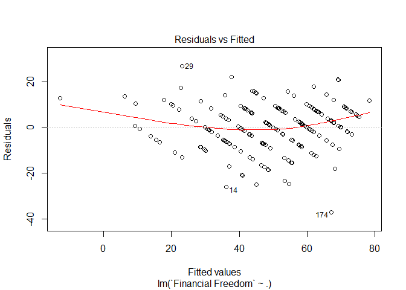

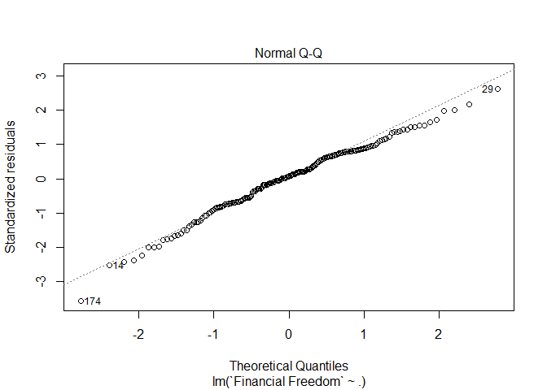

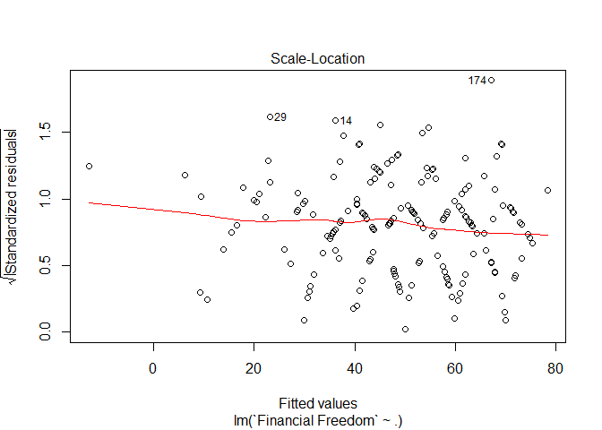

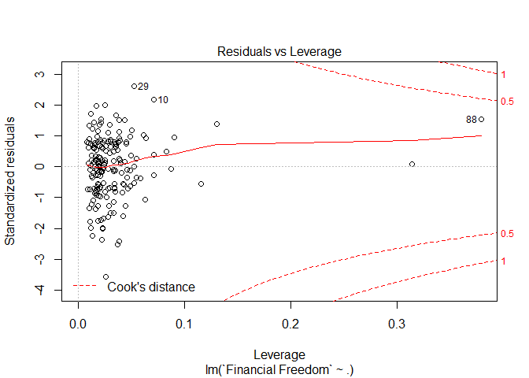

```r
plot(model_ori)
```

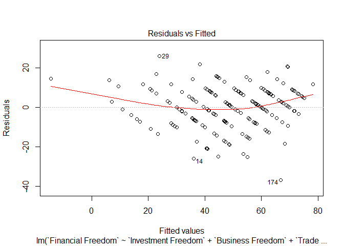

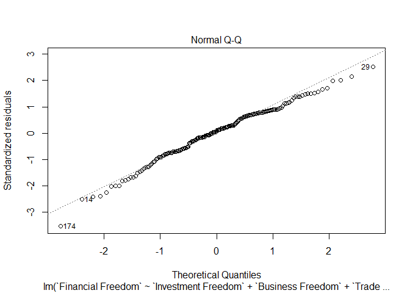

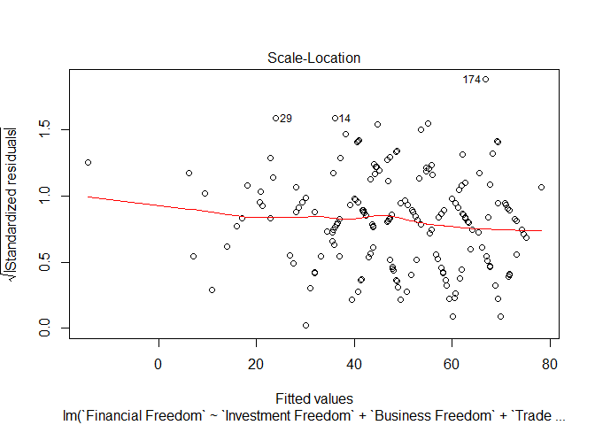

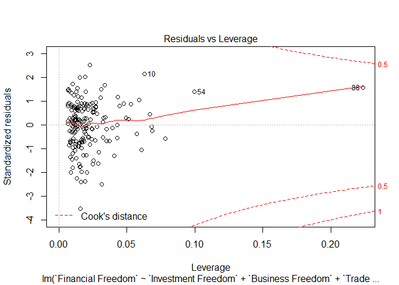

```r
plot(model_rec)
```

### Model Testing

Homoschedaticity test

```r
bptest(model_ori)
```

```
##
##  studentized Breusch-Pagan test
##
## data:  model_ori
## BP = 4.281, df = 5, p-value = 0.5097
```

```r
bptest(model_rec)
```

```
##
##  studentized Breusch-Pagan test
##
## data:  model_rec
## BP = 3.3498, df = 3, p-value = 0.3408
```

Note : both the original model (using all variables) and the recommendation model, both have p-values> 0.05, which indicates that both of these models have passed the homoschedaticity test

Shapiro Test

```r
shapiro.test(model_ori$residuals)
```

```
##
##  Shapiro-Wilk normality test
##
## data:  model_ori$residuals
## W = 0.98518, p-value = 0.05415
```

```r
shapiro.test(model_rec$residuals)
```

```
##
##  Shapiro-Wilk normality test
##
## data:  model_rec$residuals
## W = 0.98487, p-value = 0.04915
```

Note : In the Shapiro test, the original model got a p-value slightly above 0.05 and was declared to have passed the test, but for the recommended model it obtained a p-value of 0.049 which was slightly below the 0.05 standard so that it was declared not to pass the Shapiro test, shows that there are abnormalities in the linear correlation of recommendation models

Normality test (density test)

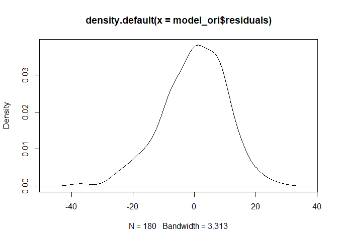

```r
plot(density(model_ori$residuals))
```

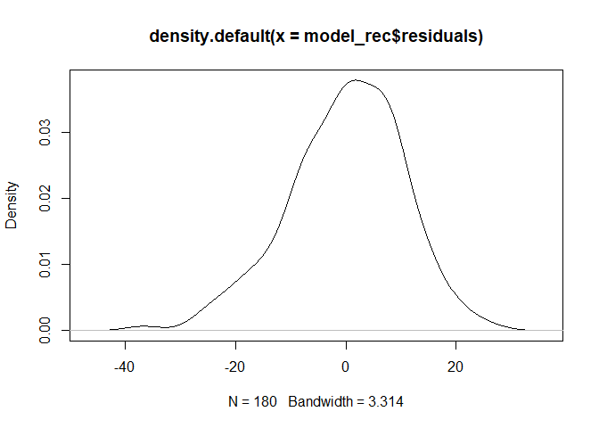

```r
plot(density(model_rec$residuals))
```

Linearity

```r
colSums(is.na(freedom))
```

```
##  Financial Freedom Investment Freedom   Business Freedom
##                  0                  0                  0
##      Labor Freedom   Monetary Freedom      Trade Freedom
##                  0                  0                  0
```

```r
# `Financial Freedom`, `Investment Freedom`, `Business Freedom`, `Labor Freedom`, `Monetary Freedom`, `Trade Freedom`
cor.test(freedom$`Financial Freedom`, freedom$`Investment Freedom`)
```

```
##
##  Pearson's product-moment correlation
##
## data:  freedom$`Financial Freedom` and freedom$`Investment Freedom`
## t = 18.612, df = 178, p-value < 2.2e-16
## alternative hypothesis: true correlation is not equal to 0
## 95 percent confidence interval:
##  0.7564133 0.8571278
## sample estimates:
##       cor
## 0.8127568
```

```r
cor.test(freedom$`Financial Freedom`, freedom$`Business Freedom`)
```

```
##
##  Pearson's product-moment correlation
##
## data:  freedom$`Financial Freedom` and freedom$`Business Freedom`
## t = 10.55, df = 178, p-value < 2.2e-16
## alternative hypothesis: true correlation is not equal to 0
## 95 percent confidence interval:
##  0.5212786 0.7027603
## sample estimates:
##       cor
## 0.6202515
```

```r
cor.test(freedom$`Financial Freedom`, freedom$`Labor Freedom`)
```

```
##
##  Pearson's product-moment correlation
##
## data:  freedom$`Financial Freedom` and freedom$`Labor Freedom`
## t = 4.648, df = 178, p-value = 6.506e-06
## alternative hypothesis: true correlation is not equal to 0
## 95 percent confidence interval:
##  0.1919602 0.4534315
## sample estimates:
##       cor
## 0.3289867
```

```r
cor.test(freedom$`Financial Freedom`, freedom$`Monetary Freedom`)
```

```
##
##  Pearson's product-moment correlation
##
## data:  freedom$`Financial Freedom` and freedom$`Monetary Freedom`
## t = 7.8268, df = 178, p-value = 4.299e-13
## alternative hypothesis: true correlation is not equal to 0
## 95 percent confidence interval:
##  0.3884871 0.6073153
## sample estimates:
##       cor
## 0.5059988
```

```r
cor.test(freedom$`Financial Freedom`, freedom$`Trade Freedom`)
```

```
##
##  Pearson's product-moment correlation
##
## data:  freedom$`Financial Freedom` and freedom$`Trade Freedom`
## t = 11.098, df = 178, p-value < 2.2e-16
## alternative hypothesis: true correlation is not equal to 0
## 95 percent confidence interval:
##  0.5441518 0.7185666
## sample estimates:
##       cor
## 0.6395164
```

Note : after running the test, all variables taken from the data have a significant linear correlation to `financial freedom` as indicated by the p-value <0.05 obtained from each of the tests

multilinearity

```r
vif(model_ori)
```

```
## `Investment Freedom`   `Business Freedom`      `Labor Freedom`
##             1.930060             2.198554             1.402769
##   `Monetary Freedom`      `Trade Freedom`
##             1.665117             2.098603
```

```r
vif(model_rec)
```

```
## `Investment Freedom`   `Business Freedom`      `Trade Freedom`
##             1.681335             1.916608             2.007786
```

Note : In the multilinearity test, the VIF (Variance Inflation Factor) value obtained by each variable gets a value <10, this indicates that all multicol negative variables and passed the assumption test

```r
summary(model_ori)
```

```
##
## Call:
## lm(formula = `Financial Freedom` ~ ., data = freedom)
##
## Residuals:
##     Min      1Q  Median      3Q     Max
## -37.149  -6.935   0.773   7.729  26.886
##
## Coefficients:
##                        Estimate Std. Error t value Pr(>|t|)
## (Intercept)          -13.883558   6.508264  -2.133  0.03431 *
## `Investment Freedom`   0.559513   0.049862  11.221  < 2e-16 ***
## `Business Freedom`     0.198461   0.074808   2.653  0.00872 **
## `Labor Freedom`        0.002326   0.064502   0.036  0.97128
## `Monetary Freedom`    -0.038323   0.092609  -0.414  0.67952
## `Trade Freedom`        0.271695   0.093939   2.892  0.00431 **
## ---
## Signif. codes:  0 '***' 0.001 '**' 0.01 '*' 0.05 '.' 0.1 ' ' 1
##
## Residual standard error: 10.55 on 174 degrees of freedom
## Multiple R-squared:  0.7126, Adjusted R-squared:  0.7043
## F-statistic: 86.28 on 5 and 174 DF,  p-value: < 2.2e-16
```

# Result

- Model Original (lm(formula = `Financial Freedom` ~ `Investment Freedom` + `Business Freedom` +`Trade Freedom` + `MOnetary Freedom` + `Labor Freedom`, data = freedom)) the original model that uses all the index freedom variables, has a significant value of r square adjustment which is at 0.7043. Test of this model test has also been carried out and shows harmony in all tests, the original model has been in accordance with the statistics that have passed the test both in the test linarity, multilinearity, shapiro test and homoschedaticity test.
- Model Recommendation (lm(formula = `Financial Freedom` ~ `Investment Freedom` + `Business Freedom` +`Trade Freedom`, data = freedom)) in the recommendation model, the `step` function simplifies the original model by removing 2 variables that have a non-significant correlation coefficient on financial freedom. adjusted r squared results obtained also increased higher than the original model. but when testing the recommendation model does not pass the Shapiro test, this shows that there are abnormalities in the linear correlation of recommendation models

Based on this test, we decided to recommend the use of original models or models that use all the freedom index variables as predictors of financial freedom.